NEH Health Humanities · Community-Engaged Research

# The First-Gen Cliff: how a comparative study reshaped a college program

A mixed-methods research project at LaGuardia Community College that quantified why first-generation students leave — and turned the evidence into a launched degree.

Gerusa de Souza · LaGuardia Community College, CUNY · Presented at the SCRA Biennial Conference, June 23, 2023

First-generation students arrive at college without a family map for how it works. We suspected that gap showed up as measurable risk — so we designed a study to find out where, when, and how much.

2

Research instruments designed & deployed

41%

First-gen students who seriously considered dropping out

+63 pp

Low-income dropout gap, first- vs second-gen

1

Health Humanities AA degree launched from the findings

## 01The question

LaGuardia's first-year retention (60%) trails the national average, and the loss is not evenly distributed. The NEH Health Humanities initiative needed evidence to design a program that would actually hold first-generation students — not assumptions. My role was to build the research that would answer one question: **what specifically puts first-gen students at risk, and when?**

## 02The design — a controlled comparison

Second-gen ≈ 45% of enrolled students (behavioral baseline) · First-gen ≈ 55% (primary group under study).

## 03Finding — first-gen students carry 2–3× the strain

Across every dimension, first-generation students scored dramatically higher on risk. Financial stress, mental-health strain, and academic-direction uncertainty were the widest gaps — each a critical difference of five points or more.

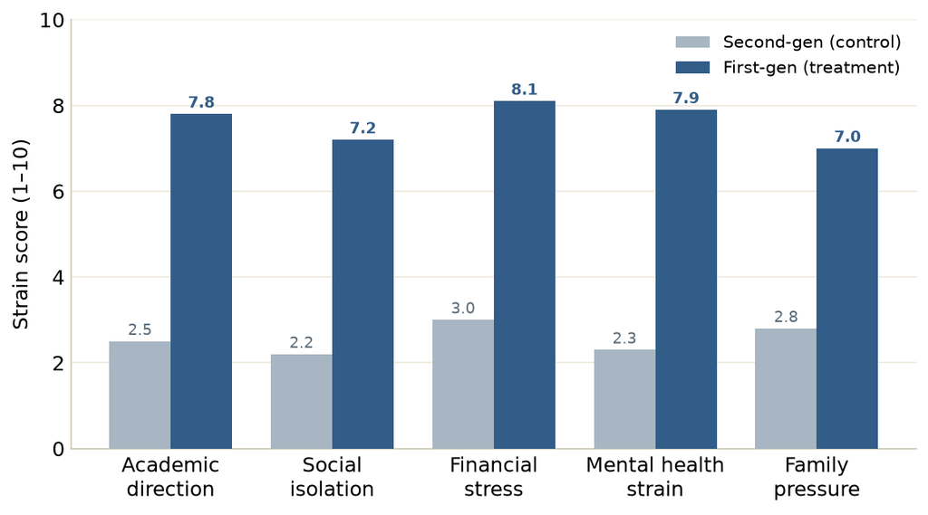

Risk strain by dimension (1–10). First-gen students score 2–3× higher across the board.

## 04Finding — the dropout cliff is Semester 1

Timing mattered as much as magnitude. First-gen dropout risk **peaks at 9.0 in the first semester**, then falls steadily as students who survive find their footing. The second-gen line stays flat and low throughout. The implication for program design was unambiguous: intervention has to land early, before the first semester ends.

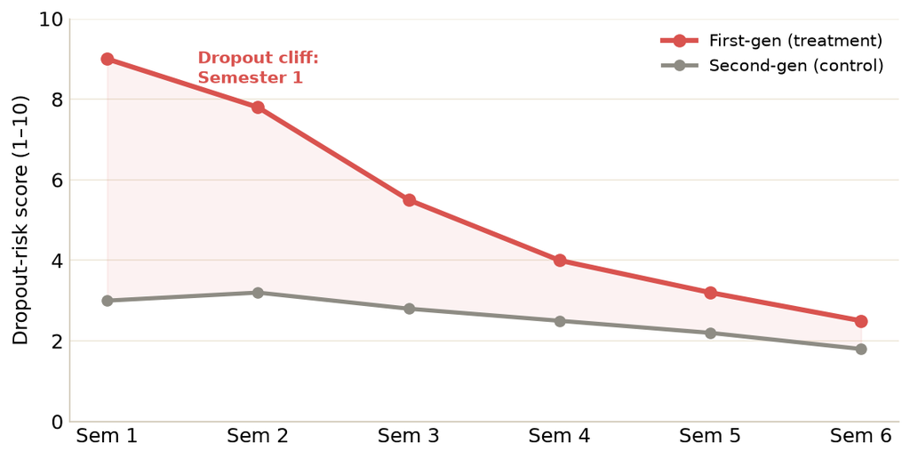

Dropout-risk timeline. The first-gen curve starts at a cliff and converges with the control only by Semester 6.

## 05Finding — the barriers are compound, and they're material

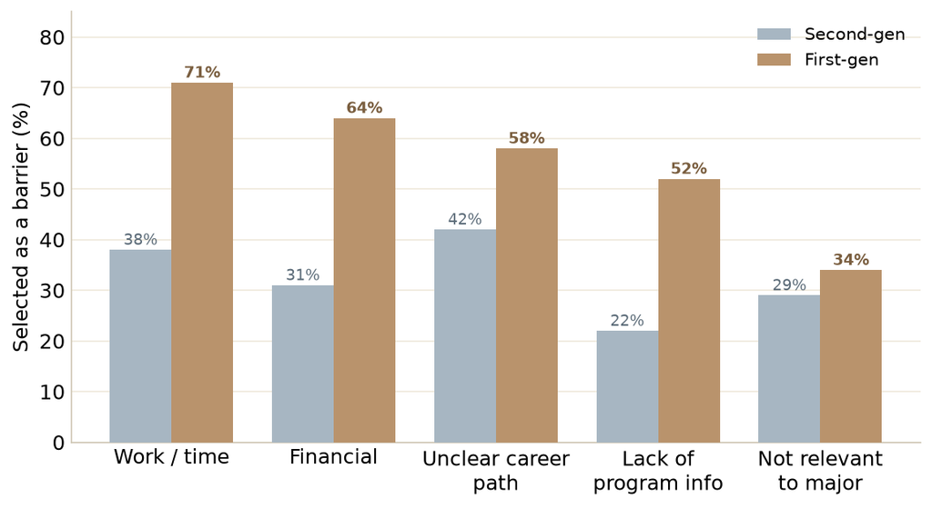

Barriers to enrollment by generation (multi-select). First-gen students face material and informational barriers at far higher rates.

## 06Context — how LaGuardia compares

The student-level gaps sit inside an institutional one. LaGuardia trails national benchmarks on retention and completion — but the CUNY ASAP comparison shows what targeted support does: a 53% outcome against a 24% control, **+29 points**. Support that's designed around the risk works.

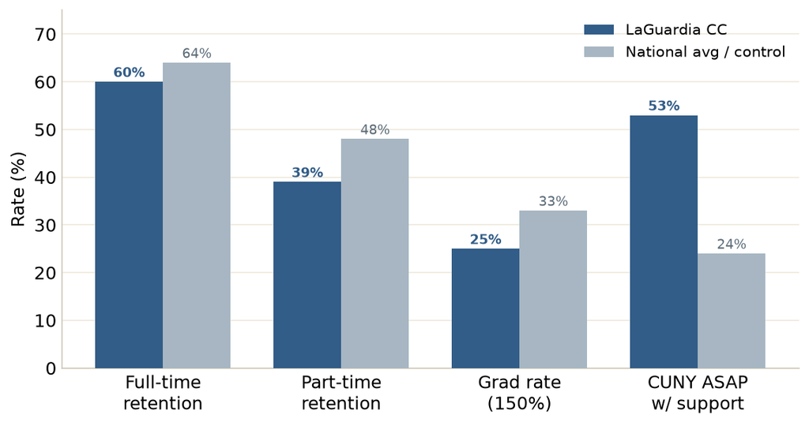

Retention and completion vs national benchmarks. ASAP-style support dramatically outperforms the control.

## 07The qualitative layer — listening before designing

Numbers tell you where; people tell you why. I coded the BRXCRRB community focus-group transcript line by line, extracting four themes that shaped how the program would be built and marketed:

| Theme | Program implication | Priority |
| --- | --- | --- |
| Research ethics & cultural sensitivity | Mandatory cultural review in instrument design | Critical |
| Inclusive outreach & equity | No-exclusion policy in data collection | Critical |
| Active information sharing | Community-embedded marketing strategy | High |
| Community infrastructure | Connect program to existing organizations | Medium |

## 08The outcome

The evidence base went to LaGuardia leadership and was presented at the SCRA Biennial Conference. The headline result isn't a chart — it's a program: the **Health Humanities AA degree is now live in the LaGuardia catalog**, designed around findings showing where first-gen students need support and when.

Student interest surveyFocus-group protocolTranscript codingEvidence baseSCRA presentationLaunched degree

## Why this is business analysis

The subject was students, but the method is the one a business analyst uses every day: define the question, design the instrument, run a controlled comparison, code the qualitative signal, and hand stakeholders something they can act on. Survey design becomes A/B variable definition; focus-group coding becomes voice-of-customer analysis; the leadership dashboard becomes KPI reporting.

> "The challenge changes — students or customers, college or telecom. The work is the same: understand what the audience needs, design the instrument to find out, analyze with rigor, and give the business something it can act on."